#### Question 1

```r
library(readr)
library(dplyr)
# import data
data1 <- read_csv("Assignment 4A.csv")
View(data1)
```

```r
# Data preparation
data1$`Average length of stay (days)`=as.numeric(data1$`Average length of stay (days)`)
data1 <- data1 %>% filter(`Local Hospital Network (LHN)` == "South Western Sydney")

# Hypothesis testing
t.test(data1$`Average length of stay (days)`, mu = 4.5, conf.level = .95, alternative= "two.sided")
```

```
##
##  One Sample t-test
##
## data:  data1$`Average length of stay (days)`
## t = 1.1346, df = 370, p-value = 0.2573
## alternative hypothesis: true mean is not equal to 4.5
## 95 percent confidence interval:
##  4.394867 4.891926
## sample estimates:
## mean of x
##  4.643396
```

Hypothesis H0: mu = 4.5 HA: mu != 4.5

As p-value is greater than 0.05, we fail to reject null hypothesis and the 95% cI[4.394867, 4.891926] of mean ALOS capture H0.

The estimated population mean ALOS based on the sample data was 4.643396, 95% CI [ 4.394867 4.891926], p = 0.2573. Hypothesis t-test found the mean ALOS is not signiﬁcantly different from 4.5.

#### Question 2

```r
library(readr)
library(dplyr)

#import data
data2 <- read_csv("Assignment 4b-1.csv")
View(data2)
```

```r
# Create differences (d) column
data2 <- data2 %>%  mutate (d = `Score without after tutorial`- `Score without before tutorial`)
```

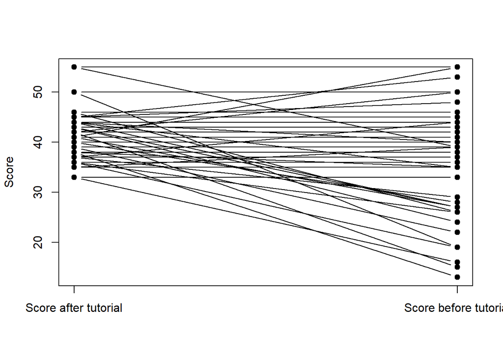

```r
# Visualisation
matplot(t(data.frame(data2$`Score without after tutorial`,
                     data2$`Score without before tutorial`)),
        type="b", pch=19, col=1, lty=1, xlab= "", ylab="Score", xaxt = "n")
axis(1, at=1:2, labels=c("Score after tutorial","Score before tutorial"))
```

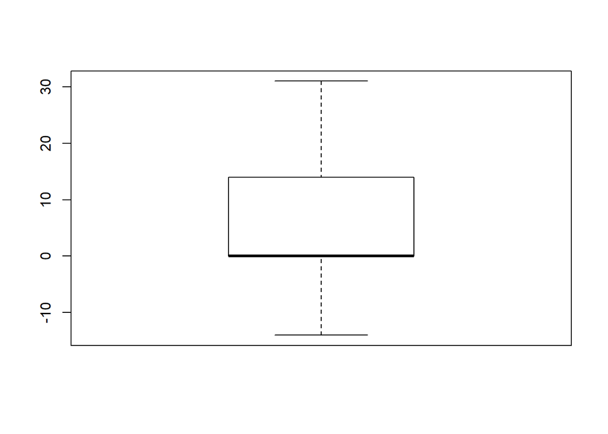

```r
# Any outliers?
boxplot(data2$d)
```

Boxplot shows that there are no outliers.

```r
# Check normality of difference scores
library(car)
```

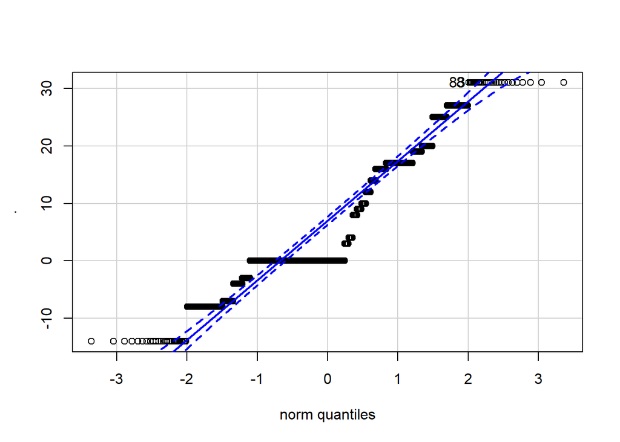

```
## [1]  8 83
```

```r
data2$d %>% qqPlot(dist="norm")
```

The sample size is 1290 (n > 30), we don’t have to worry about normality, even though some of points fall outside the lines.

```r
# Conduct Paired sample t-test
# H0: mu_after = mu_before, HA: mu_after != mu_before
t.test(data2$`Score without after tutorial`,
       data2$`Score without before tutorial`,
       paired = TRUE,
       conf.level = .95 )
```

```
##
##  Paired t-test
##
## data:  data2$`Score without after tutorial` and data2$`Score without before tutorial`
## t = 19.144, df = 1289, p-value < 2.2e-16
## alternative hypothesis: true difference in means is not equal to 0
## 95 percent confidence interval:
##  4.802104 5.898671
## sample estimates:
## mean of the differences
##                5.350388
```

```r
# HA: mu_after > mu_before
t.test(data2$`Score without after tutorial`,
       data2$`Score without before tutorial`,
       paired = TRUE,
       alternative = "greater",
       conf.level = .95 )
```

```
##
##  Paired t-test
##
## data:  data2$`Score without after tutorial` and data2$`Score without before tutorial`
## t = 19.144, df = 1289, p-value < 2.2e-16
## alternative hypothesis: true difference in means is greater than 0
## 95 percent confidence interval:
##  4.890355      Inf
## sample estimates:
## mean of the differences
##                5.350388
```

I perform a hypothesis test to determine if there is a statistical evidence that “Score after tutorial” is greater than “Score after tutorial”.

In the first testing, as p-value is less than 0.05, we refect H0. The results of the study found a statistically signiﬁcant mean difference between scores after tutorials and scores before tutorials, t(df = 1289) = 19.144, p < 0.01, 95% CI for the difference in means [4.802104 5.898671].

In the second testing, as p-value is less than 0.05, we reject H0. In addition, the mean of the differences is 5.350388. This indicates that mean score after tutorial is higher than mean score before tutorial.

Therefore, tutorials are effective in improving students’ performance.